# Final Visuals

By: Mayra Smith-Coronado

05 September, 2020

## Exercise 1

Use data from the CDC available for download from [here](https://covid.cdc.gov/covid-data-tracker/#cases) to create a map showing US COVID-19 case incidence per 100,000 in the last 7 days. You’ll also need to find and use state-level population estimates. Please only include the 48 continental US states, Alaska, and Hawaii in your final figure.

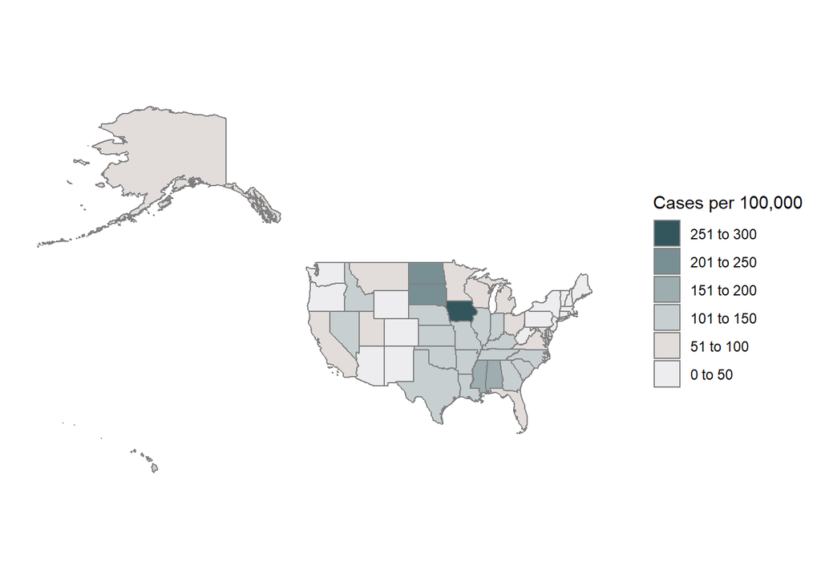

## Exercise 2

Use state-level historical data from the COVID Tracking Project to visualize

- The 7-day moving average of new cases reported per 100,000
- The 7-day moving average of daily PCR tests conducted per 100,000 people
- The 7-day moving average of percent positivity (person-level positive PCR tests divided by the total number of people who received a PCR test each day)

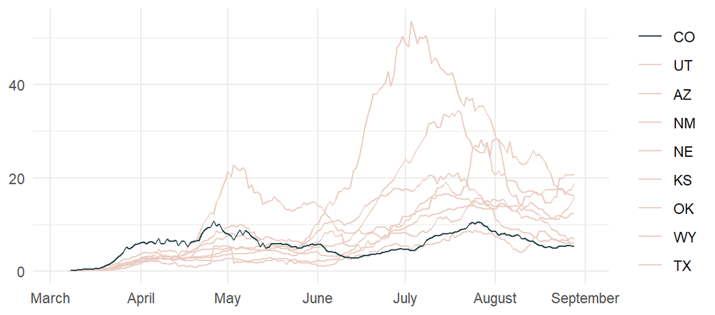

The number of daily PCR tests conducted per 100,000 people continues to grow in Colorado.

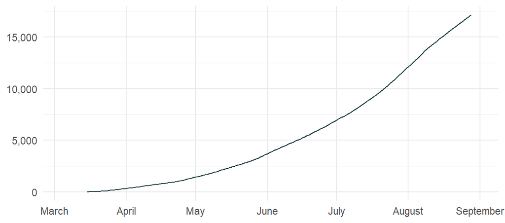

The percent positivity continues to decrease in Colorado.

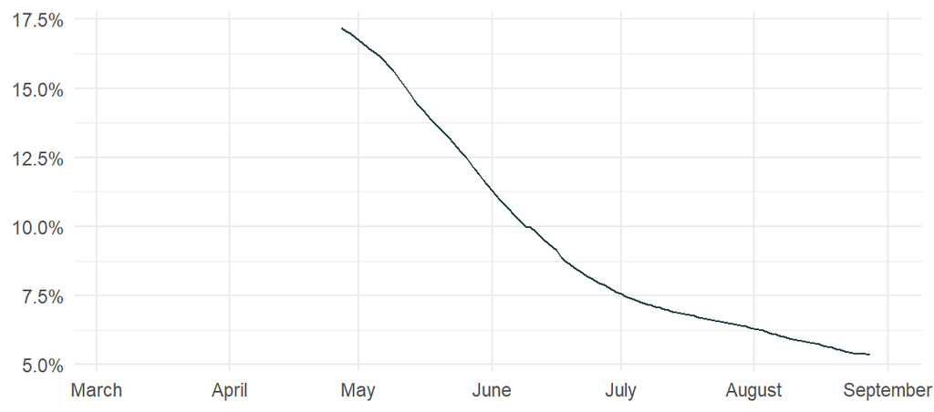